# homework 7

Italo Carvalho Vianelli Ribeiro

15/07/2020

Homework 7 - RA 769687

```
## No updates are available
```

```
##         date province     country      lat     long      type cases
## 1 2020-01-22          Afghanistan 33.93911 67.70995 confirmed     0
## 2 2020-01-23          Afghanistan 33.93911 67.70995 confirmed     0
## 3 2020-01-24          Afghanistan 33.93911 67.70995 confirmed     0
## 4 2020-01-25          Afghanistan 33.93911 67.70995 confirmed     0
## 5 2020-01-26          Afghanistan 33.93911 67.70995 confirmed     0
## 6 2020-01-27          Afghanistan 33.93911 67.70995 confirmed     0
```

Durante o início da pandemia, a Itália era um dos países mais comentados, que estava com um alto número de casos e por isso resolvi começar analisando os números de casos na Italia

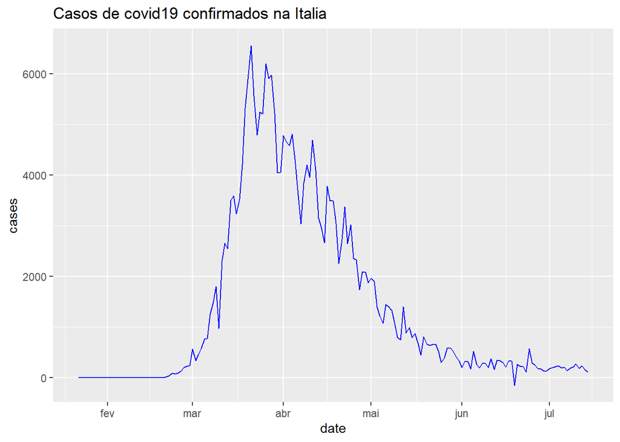

```r
confirmadosItalia = coronavirus%>%filter(country=="Italy",
                     type == "confirmed")

ggplot(confirmadosItalia)+
                     geom_line(mapping = aes(x=date,
                                          y = cases),
           color = "blue") +
  labs(title="Casos de covid19 confirmados na Italia")
```

E agora vamos veerificar o do Brasil, e podemos perceber que os números do Brasil são maiores comparado ao gráfico anterior da Italia, e mesmo comparado com a Italia tendo um crescimento de casos mais tardio, atualmente seu números vem crescendo cada vez mais, enquanto a Italia aparenta estar conseguindo conter melhor o número de casos de covid-19 atualmente se comparado ao Brasil

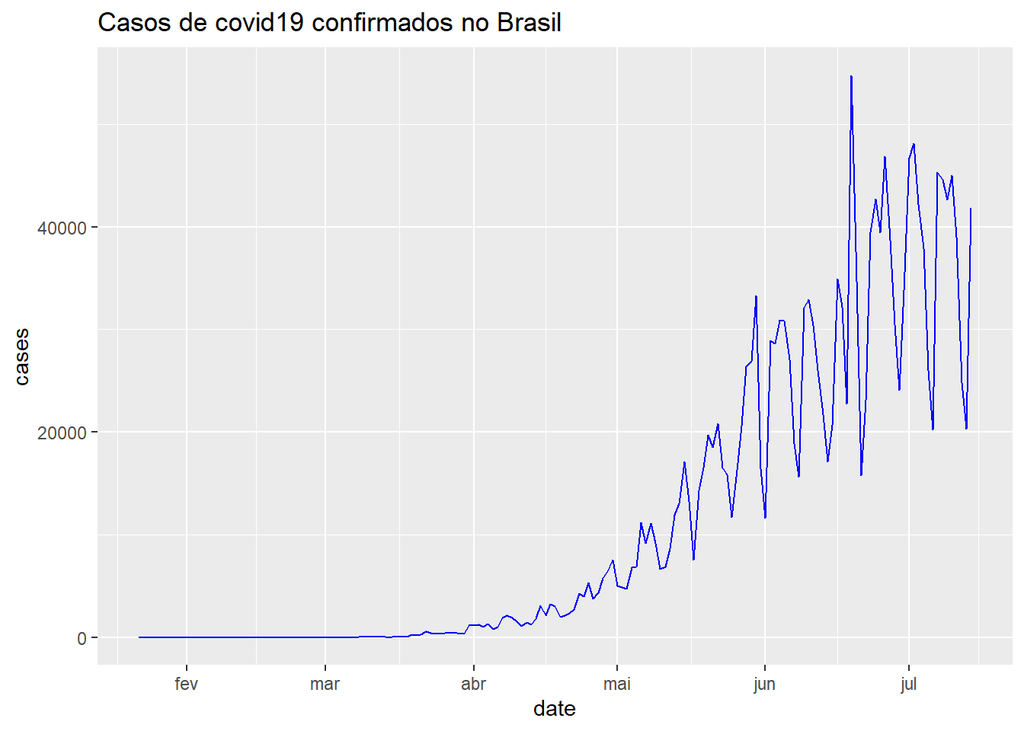

```r
confirmadosBrasil = coronavirus%>%filter(country=="Brazil",
                     type == "confirmed")

ggplot(confirmadosBrasil)+
                     geom_line(mapping = aes(x=date,
                                          y = cases),
           color = "blue") +
  labs(title="Casos de covid19 confirmados no Brasil")
```

Após fazer essa análise resolvi verificar como estão os casos acumulados nos países da Ásia que rodeiam a China, o país que originou covid-19.Mesmo a Mongolia sendo um país pequeno, é interessante notar o controle deles, principalmente sendo um país vizinho colado na China que foi onde se originou a covid-19

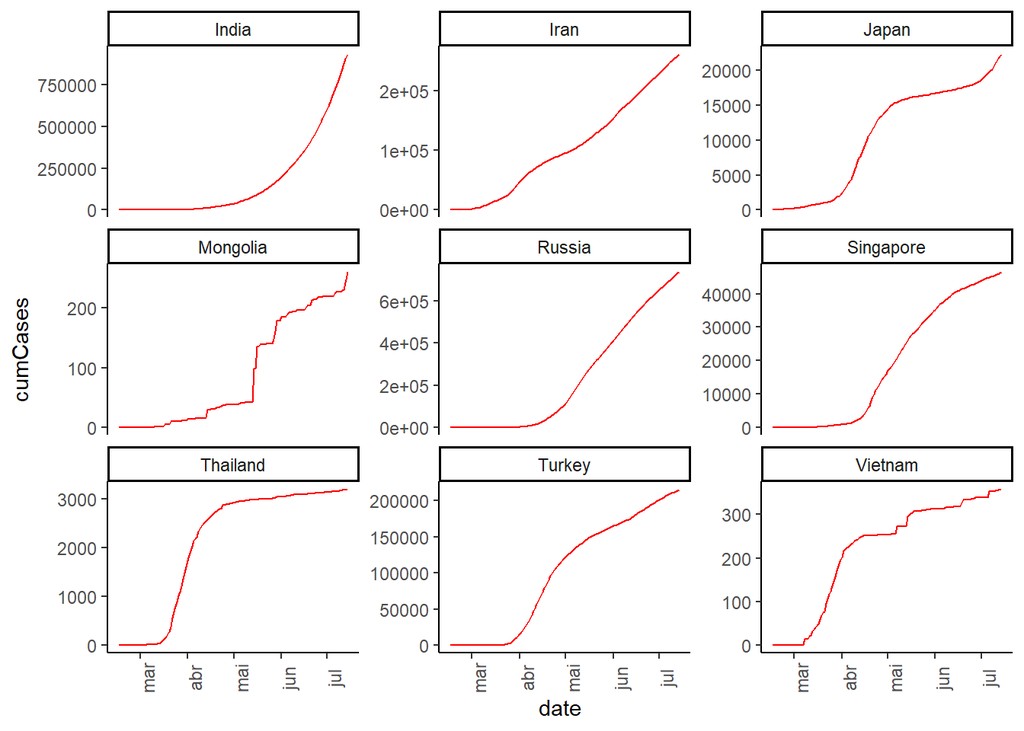

```r
asia = coronavirus %>% filter(country %in% c("Iran","India","Russia","Thailand", "Japan", "Vietnam", "Turkey", "Singapore", "Mongolia"), type=="confirmed", date>as.Date("2020-02-15"))%>% group_by(type, country) %>% mutate(
  cumCases = cumsum(cases))



ggplot(asia, aes(x=date, y=cumCases)) +
   geom_line(color="red") +   facet_wrap(~country, ncol=3, scales="free_y") +
   theme_classic() +
    theme(axis.text.x = element_text(angle = 90))
```

Em sequência resolvi analisar os países europeus, e mesmo no começo da pandemia a Italia estar disparado com número de casos acumulados como se pode observar, atualmente o Reino Unido e a Espanha são os países que estão com o maior número de casos acumulados, não conseguindo lidar com a contenção de casos de covid 19

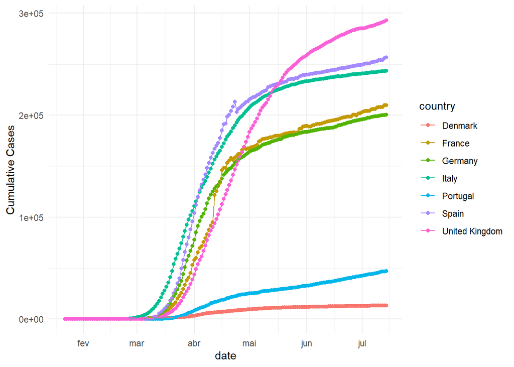

```r
coronavirus%>%mutate(date=as.Date(date))%>%
  filter(country %in% c("Italy","Portugal","Denmark","Spain", "France", "United Kingdom", "Germany", "Swedish"), type=="confirmed")%>%

  group_by(date, country)%>%summarise(Daily_Cases=sum(cases))%>%
  group_by(country)%>%arrange(date)%>%
  mutate(Agg_Cases=cumsum(Daily_Cases))%>%
  ggplot(aes(x=date, y=Agg_Cases, col=country))+geom_point()+geom_line()+ylab("Cumulative Cases")+theme_minimal()
```

```r
death_eu<-coronavirus%>%mutate(date=as.Date(date))%>%
  filter(country %in% c("Italy","Portugal","Denmark","Spain", "France", "United Kingdom", "Germany", "Swedish"), type=="death")%>%
  group_by(date, country)%>%summarise(Daily_Cases=sum(cases))%>%group_by(country)%>%arrange(date)%>%
  mutate(Agg_Cases=cumsum(Daily_Cases), Diff=Daily_Cases/lag(Daily_Cases)-1)%>%arrange(desc(date))%>%slice(1)%>%select(date, country, Agg_Deaths=Agg_Cases, Yestrday_Deaths=Daily_Cases, Change_in_Daily_Deaths=Diff)

death_eu
```

```
## # A tibble: 7 x 5
## # Groups:   country [7]
##   date       country        Agg_Deaths Yestrday_Deaths Change_in_Daily_Deaths
##   <date>     <chr>               <int>           <int>                  <dbl>
## 1 2020-07-14 Denmark               610               0                 -1
## 2 2020-07-14 France              30032               0                 -1
## 3 2020-07-14 Germany              9078               4                  0.333
## 4 2020-07-14 Italy               34984              17                  0.308
## 5 2020-07-14 Portugal             1668               6                  2
## 6 2020-07-14 Spain               28409               3                  0
## 7 2020-07-14 United Kingdom      45053             138                 11.5
```

Após analisar esses dados resolvi analisar a situação da Italia, e pude observar que eles estão conseguindo diminuir a curva de casos e mortes, como analisado anteriormente, e consequente uma boa taxa de recuperados

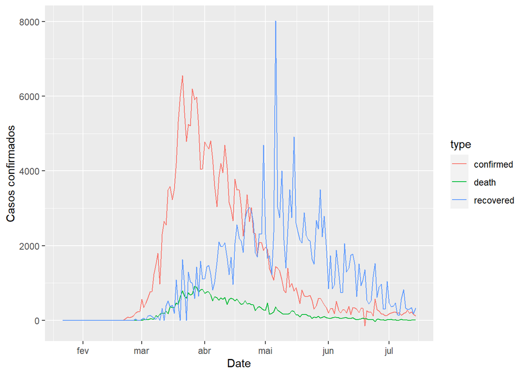

```r
library(tidyr)

casos_italia <- coronavirus %>%
  filter(country =='Italy') %>%
  select(date, country, type, cases) %>%
  group_by(date)
#Agora, vamos calcular as variáveis de interesse
Italia_taxas <- casos_italia %>%
  filter(date >= '2020-03-01') %>%
  group_by (date, type) %>%
  summarize (total = sum(cases)) %>%
  pivot_wider (names_from = type,
               values_from = total) %>%
  arrange (date) %>%
  ungroup() %>%
  mutate(active = confirmed - death,
         cum_active = cumsum(active),
         cum_confirm = cumsum(confirmed),
         cum_death = cumsum(death),
         cum_recovered = cumsum(recovered))
df <- as.data.frame(casos_italia)


ggplot(casos_italia) +
  geom_line(aes(x=date, y=cases, group = type, color = type)) +
  ylab("Casos confirmados")+
  xlab("Date")
```

Em seguida, resolvi analisar a situação da Espanha, que como podemos ter visto anteriormente, é um dos países da Europa com maior casos acumulados de covid-19. E podemos verificar que mesmo tendo uma controlada nos casos, a curva de casos permanece superior a de recuperados

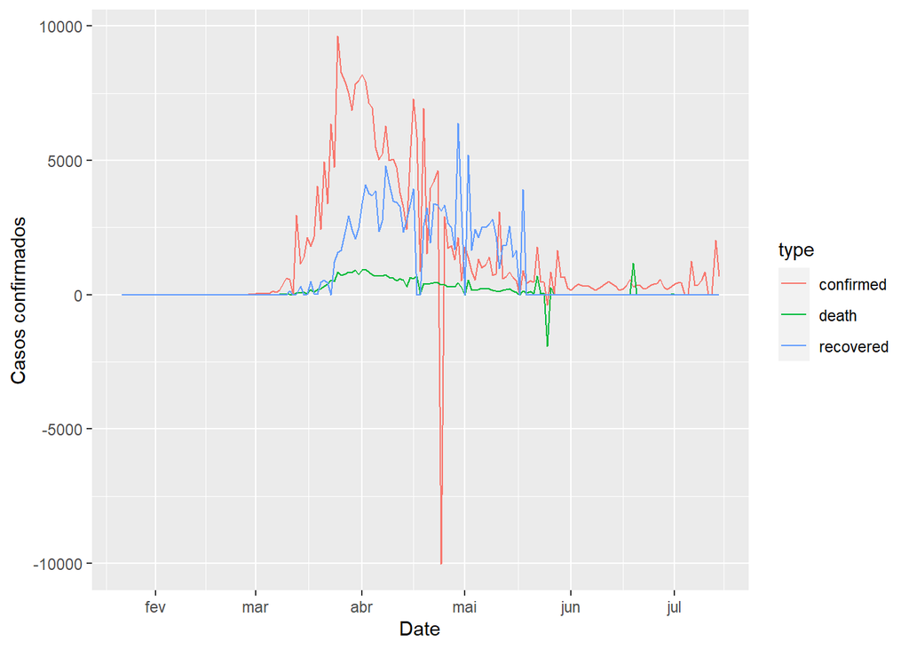

```r
casos_espanha <- coronavirus %>%
  filter(country =='Spain') %>%
  select(date, country, type, cases) %>%
  group_by(date)
#Agora, vamos calcular as variáveis de interesse
espanha_taxas <- casos_espanha %>%
  filter(date >= '2020-03-01') %>%
  group_by (date, type) %>%
  summarize (total = sum(cases)) %>%
  pivot_wider (names_from = type,
               values_from = total) %>%
  arrange (date) %>%
  ungroup() %>%
  mutate(active = confirmed - death,
         cum_active = cumsum(active),
         cum_confirm = cumsum(confirmed),
         cum_death = cumsum(death),
         cum_recovered = cumsum(recovered))
df <- as.data.frame(casos_espanha)


ggplot(casos_espanha) +
  geom_line(aes(x=date, y=cases, group = type, color = type)) +
  ylab("Casos confirmados")+
  xlab("Date")
```

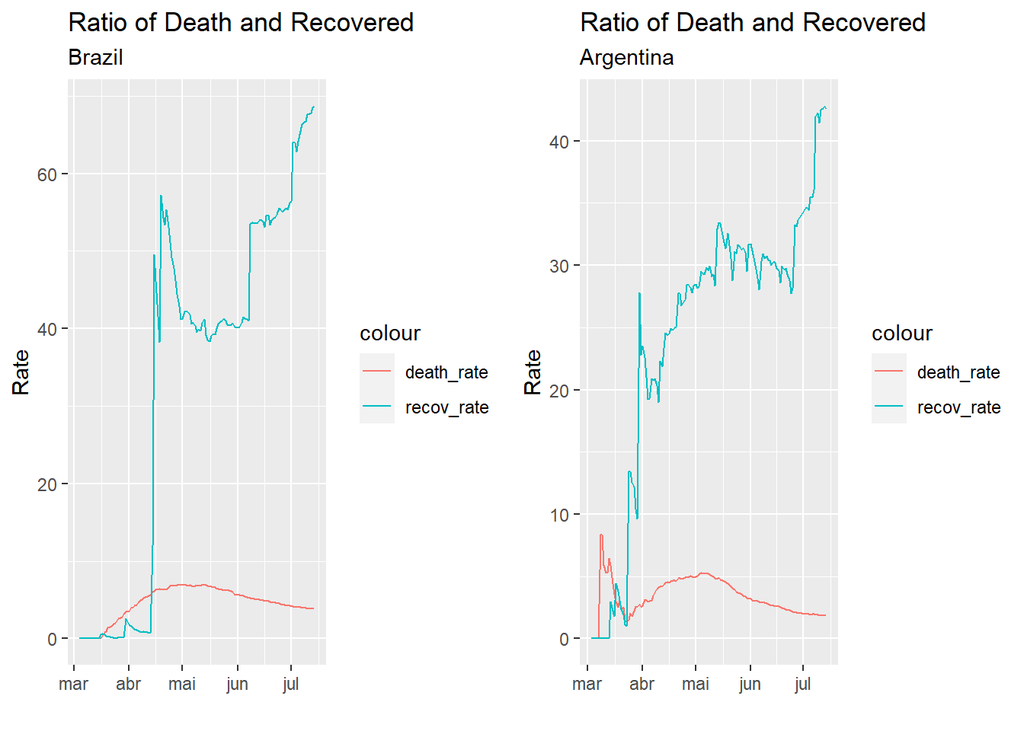

```r
cases_brazil <- coronavirus %>%
  filter(country =='Brazil') %>%
  select(date, country, type, cases) %>%
  group_by(date)
Brazil_taxas <- cases_brazil %>%
  filter(date >= '2020-03-01') %>%
  group_by (date, type) %>%
  summarize (total = sum(cases)) %>%
  pivot_wider (names_from = type,
               values_from = total) %>%
  arrange (date) %>%
  ungroup() %>%
  mutate(active = confirmed - death,
         cum_active = cumsum(active),
         cum_confirm = cumsum(confirmed),
         cum_death = cumsum(death),
         cum_recovered = cumsum(recovered))


cases_argentina <- coronavirus %>%
  filter(country =='Argentina') %>%
  select(date, country, type, cases) %>%
  group_by(date)
#Agora, vamos calcular as variáveis de interesse
Argentina_taxas <- cases_argentina %>%
  filter(date >= '2020-03-01') %>%
  group_by (date, type) %>%
  summarize (total = sum(cases)) %>%
  pivot_wider (names_from = type,
               values_from = total) %>%
  arrange (date) %>%
  ungroup() %>%
  mutate(active = confirmed - death,
         cum_active = cumsum(active),
         cum_confirm = cumsum(confirmed),
         cum_death = cumsum(death),
         cum_recovered = cumsum(recovered))

ratio <- Brazil_taxas %>%
              group_by(date) %>%
              summarise(death = sum(cum_death), confirmed = sum(cum_confirm),recovered = sum(cum_recovered)) %>%
              mutate(recov_rate = 100*(recovered/confirmed))%>%
              mutate(death_rate = 100*(death/confirmed))
Ratio <- na.omit(ratio)
gbrasil <- ggplot(Ratio) +
    geom_line(aes(x=date, y= death_rate, color = 'death_rate')) +
    geom_line(aes(x=date, y= recov_rate, color = 'recov_rate')) +
    labs(x = "", y = 'Rate', title = 'Ratio of Death and Recovered',
       subtitle = 'Brazil')

ratio <- Argentina_taxas %>%
              group_by(date) %>%
              summarise(death = sum(cum_death), confirmed = sum(cum_confirm),recovered = sum(cum_recovered)) %>%
              mutate(recov_rate = 100*(recovered/confirmed))%>%
              mutate(death_rate = 100*(death/confirmed))
Ratio <- na.omit(ratio)
gargentina <- ggplot(Ratio) +
    geom_line(aes(x=date, y= death_rate, color = 'death_rate')) +
    geom_line(aes(x=date, y= recov_rate, color = 'recov_rate')) +
    labs(x = "", y = 'Rate', title = 'Ratio of Death and Recovered',
       subtitle = 'Argentina')

grid.arrange(gbrasil, gargentina, ncol=2)
```